# Lateral connectivity analysis

Author

Leonardo Capitani

Published

September 4, 2026

```r
invisible(Sys.setlocale("LC_CTYPE", "en_US.UTF-8"))  # print non-ASCII (Delta, arrows) correctly

# Load libraries
library(tidyverse)
library(here)
library(DT)
library(ggdist)
library(scales)
library(readxl)
library(chron)# for time formatting
library(brms)
library(tidybayes)
library(dplyr)
library(stringr)
library(bayesplot)
library(dagitty)
```

## Introduction

This notebook will present additional analysis in regard to the following research question:

**TipResearch question:**

Controlling for beaver engineering effects, to what extent does lateral stream connectivity influence dissolved organic carbon (DOC) concentration ?

**Important**

Please refer to Kaspar Berger’s Master thesis, chapter 4.12.4 and chapter 5.5 to get details about the definition of stream later connectivity.

In this study, we are going to use Berger’s methodology to define stream lateral connectivity: `lateral_connectivity` is a categorical vcariable with three levels.

- `No_wetland`: no presence of wetland around the stream course,
- `yes_not connected`: presence of wetland not directly connected to the stream (figure 1a),
- `yes_connected` : presence of wetland and it is connected to the stream (figure 1b).

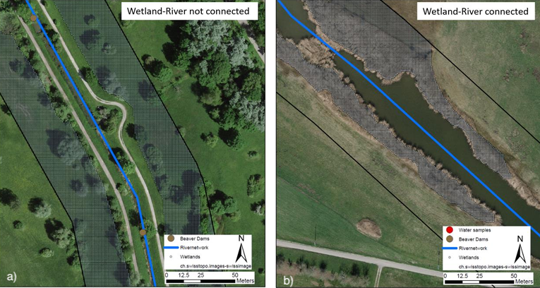

Figure 1: **The three levels of `lateral_connectivity`.** Two streams with contrasting lateral connectivity to an adjacent wetland: on the left a wetland present but not directly connected to the channel (`yes_not_connected`), on the right a wetland hydrologically connected to the channel (`yes_connected`). Sites with no wetland within the 50 m buffer are coded `No_wetland`. Image by Kaspar Berger.

Please note our main results:

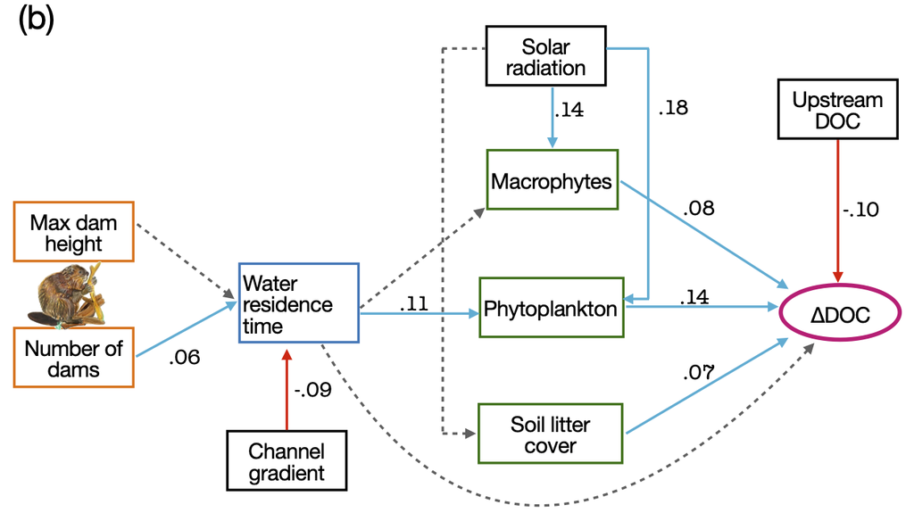

Figure 2: **The main structural causal model, for reference (manuscript Figure 1b).** Drivers of beaver-mediated DOC change: solid edges (red = negative, blue = positive) carry at least 90% posterior probability of a directional effect, dashed edges are inconclusive. Values are standardized average effects. The path this notebook extends is water residence time (`WRT`), to which `lateral_connectivity` is added as an additional parent.

We do already know that the mediating path (WRT → ΔDOC) is weak because an increase in WRT influence 1-2% the `deltaDOC`.

## DAG

Let’s define our causal diagram where predictors (`lateral_connectivity`) and response variable (`deltaDOC`) are connected by causal influences. Recall that WRT is the water residence time.

We do know that stream lateral connectivity to a wetland creates an additional storage and exchange compartment for stream water — when a wetland is hydrologically connected, water can move laterally into and out of that storage zone, increasing the time it spends in the system before continuing downstream. This mechanism is well established in the hydrology literature on stream-floodplain/wetland exchange, where connected off-channel storage areas are consistently shown to extend residence time relative to channels lacking such lateral exchange (transient storage zone theory; Bencala & Walters 1983; Wohl 2021, *Rev. Geophys.*).

**Hypothesis:**

We hypothesize that if a stream is connected to the adjacent wetland then the beaver pond water residence time varies with the degree of lateral connectivity between the stream and adjacent wetlands.

```r
dag <- dagitty('dag {
Max_dam_height [pos="-0.991,0.879"]
WRT [pos="-0.510,0.684"]
channel_gradient [pos="-0.518,0.295"]
delta_DOC [outcome,pos="0.990,0.636"]
lateral_connectivity [exposure,pos="-0.503,1.098"]
macrophytes [pos="0.373,0.249"]
number_dams [pos="-0.977,0.506"]
phytoplankton [pos="0.323,0.736"]
soil_litter [pos="0.288,1.289"]
solar_radiation [pos="-0.159,-0.285"]
upstream_DOC [pos="0.878,0.164"]
Max_dam_height -> WRT
WRT -> macrophytes
WRT -> phytoplankton
channel_gradient -> WRT
lateral_connectivity -> WRT
macrophytes -> delta_DOC
number_dams -> WRT
phytoplankton -> delta_DOC
soil_litter -> delta_DOC
solar_radiation -> WRT
solar_radiation -> macrophytes
solar_radiation -> phytoplankton
solar_radiation -> soil_litter
upstream_DOC -> delta_DOC
}

'
)

#plot(dag)
```

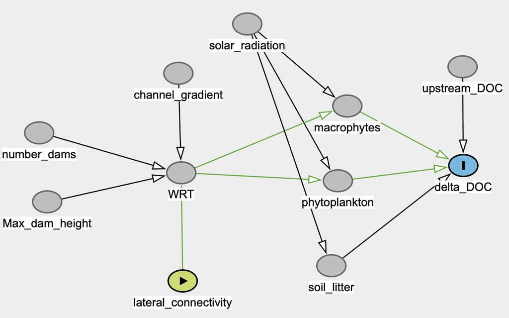

So in this DAG, there are exactly **two open front-door paths**:

1. lateral_connectivity → WRT → macrophytes → delta_DOC
2. lateral_connectivity → WRT → phytoplankton → delta_DOC

If our question question is: how much does connectivity influence DOC overall, then:

The total effect of `lateral_connectivity` on `delta_DOC` is the *sum of all causal influence* flowing through every open path — direct arrow (if any) plus every mediated pathway (through `WRT`, `macrophytes`, `phytoplankton`, `soil_litter`, etc.).

```r
# Step 3-4: backdoor paths and adjustment sets, for TOTAL effect
adjustmentSets(dag, exposure = "lateral_connectivity", outcome = "delta_DOC", effect = "total")
```

```
 {}
```

```r
# list the open paths (the orange front-door paths in Appendix S1: Figure S8)
paths(dag, "lateral_connectivity", "delta_DOC")
```

```
$paths
[1] "lateral_connectivity -> WRT -> macrophytes -> delta_DOC"
[2] "lateral_connectivity -> WRT -> macrophytes <- solar_radiation -> phytoplankton -> delta_DOC"
[3] "lateral_connectivity -> WRT -> macrophytes <- solar_radiation -> soil_litter -> delta_DOC"
[4] "lateral_connectivity -> WRT -> phytoplankton -> delta_DOC"
[5] "lateral_connectivity -> WRT -> phytoplankton <- solar_radiation -> macrophytes -> delta_DOC"
[6] "lateral_connectivity -> WRT -> phytoplankton <- solar_radiation -> soil_litter -> delta_DOC"
[7] "lateral_connectivity -> WRT <- solar_radiation -> macrophytes -> delta_DOC"
[8] "lateral_connectivity -> WRT <- solar_radiation -> phytoplankton -> delta_DOC"
[9] "lateral_connectivity -> WRT <- solar_radiation -> soil_litter -> delta_DOC"

$open
[1]  TRUE FALSE FALSE  TRUE FALSE FALSE FALSE FALSE FALSE
```

Since there’s no backdoor path (nothing causes `lateral_connectivity`), there’s nothing to adjust for — you want all those mediator paths to stay open so their contribution is captured in the estimate. That’s why the answer is `{}`.

We conclude that:

**No open biasing paths.**

No adjustment is necessary to estimate the total effect of lateral_connectivity on delta_DOC.